# 2026 Survey Summary

2026-11-23

## SSB Estimates

### LRP Data

#### Total

`Scots Bay and German Bank herring biomass, using HSC biomass numbers only. Scots Bay and German Bank have had turnover applied.`

[interactive chart not shown]

`Herring biomass including Seal Island. using HSC biomass numbers only. Scots Bay and German Bank have had turnover applied. Seal Island biomass numbers do NOT include turn over as this was a recent addition to the index.`

[interactive chart not shown]

`Scots Bay and German Bank herring biomass using HSC biomass numbers only. Scots Bay and German Bank have had turnover applied.`

|  | Year | Scots Bay | German Bank | Biomass (mt) | LRP | 3yr Avg | Difference |
| --- | --- | --- | --- | --- | --- | --- | --- |
| 1 | 2026 | 238863 | 191609 | 430472 | 317846 | 388556 | 70710 |
| 2 | 2025 | 287912 | 95831 | 383743 | 317846 | 335167 | 17321 |
| 3 | 2024 | 282742 | 68711 | 351453 | 317846 | 310687 | -7159 |
| 4 | 2023 | 204189 | 66116 | 270305 | 317846 | 267679 | -50167 |
| 5 | 2022 | 241020 | 69282 | 310302 | 317846 | 287944 | -29902 |
| 6 | 2021 | 90764 | 131667 | 222431 | 317846 | 293909 | -23937 |
| 7 | 2020 | 191649 | 139450 | 331099 | 317846 | 307891 | -9955 |
| 8 | 2019 | 151943 | 176253 | 328196 | 317846 | 323082 | 5236 |
| 9 | 2018 | 149018 | 115359 | 264377 | 317846 |  |  |
| 10 | 2017 | 177060 | 199614 | 376674 | 317846 |  |  |

`Herring biomass including Seal Island using HSC biomass numbers only. Scots Bay and German Bank have had turnover applied. Seal Island biomass numbers do NOT include turnover as this was a recent addition to the index.`

|  | Year | Scots Bay | German Bank | Seal Isl. | Biomass incl. Seal (mt) | LRP | 3yr Avg incl. Seal | Difference |
| --- | --- | --- | --- | --- | --- | --- | --- | --- |
| 1 | 2026 | 238863 | 191609 | 59699 | 490171 | 317846 | 446897 | 129051 |
| 2 | 2025 | 287912 | 95831 | 50819 | 434562 | 317846 | 400586 | 82740 |
| 3 | 2024 | 282742 | 68711 | 64504 | 415957 | 317846 | 366968 | 49122 |
| 4 | 2023 | 204189 | 66116 | 80933 | 351238 | 317846 | 306480 | -11366 |
| 5 | 2022 | 241020 | 69282 | 23408 | 333710 | 317846 | 301301 | -16545 |
| 6 | 2021 | 90764 | 131667 | 12062 | 234493 | 317846 | 313040 | -4806 |
| 7 | 2020 | 191649 | 139450 | 4601 | 335700 | 317846 | 333616 | 15770 |
| 8 | 2019 | 151943 | 176253 | 40730 | 368926 | 317846 |  |  |
| 9 | 2018 | 149018 | 115359 | 31844 | 296221 | 317846 |  |  |

#### Scots Bay

[interactive chart not shown]

|  | Year | Scots Bay |
| --- | --- | --- |
| 1 | 2026 | 238863 |
| 2 | 2025 | 287912 |
| 3 | 2024 | 282742 |
| 4 | 2023 | 204189 |
| 5 | 2022 | 241020 |
| 6 | 2021 | 90764 |
| 7 | 2020 | 191649 |
| 8 | 2019 | 151943 |
| 9 | 2018 | 149018 |
| 10 | 2017 | 177060 |

#### German Bank

[interactive chart not shown]

|  | Year | German Bank with turnover | Seal Isl. without turnover |
| --- | --- | --- | --- |
| 1 | 2026 | 191609 | 59699 |
| 2 | 2025 | 95831 | 50819 |
| 3 | 2024 | 68711 | 64504 |
| 4 | 2023 | 66116 | 80933 |
| 5 | 2022 | 69282 | 23408 |
| 6 | 2021 | 131667 | 12062 |
| 7 | 2020 | 139450 | 4601 |
| 8 | 2019 | 176253 | 40730 |
| 9 | 2018 | 115359 | 31844 |
| 10 | 2017 | 199614 |  |

#### Seal Island

[interactive chart not shown]

|  | Year | Seal Isl. without turnover |
| --- | --- | --- |
| 1 | 2026 | 59699 |
| 2 | 2025 | 50819 |
| 3 | 2024 | 64504 |
| 4 | 2023 | 80933 |
| 5 | 2022 | 23408 |
| 6 | 2021 | 12062 |
| 7 | 2020 | 4601 |
| 8 | 2019 | 40730 |
| 9 | 2018 | 31844 |
| 10 | 2017 |  |

### Total SSB Summaries

#### Total

`HSC spawning stock biomass estimates for Scots Bay and German Bank.`

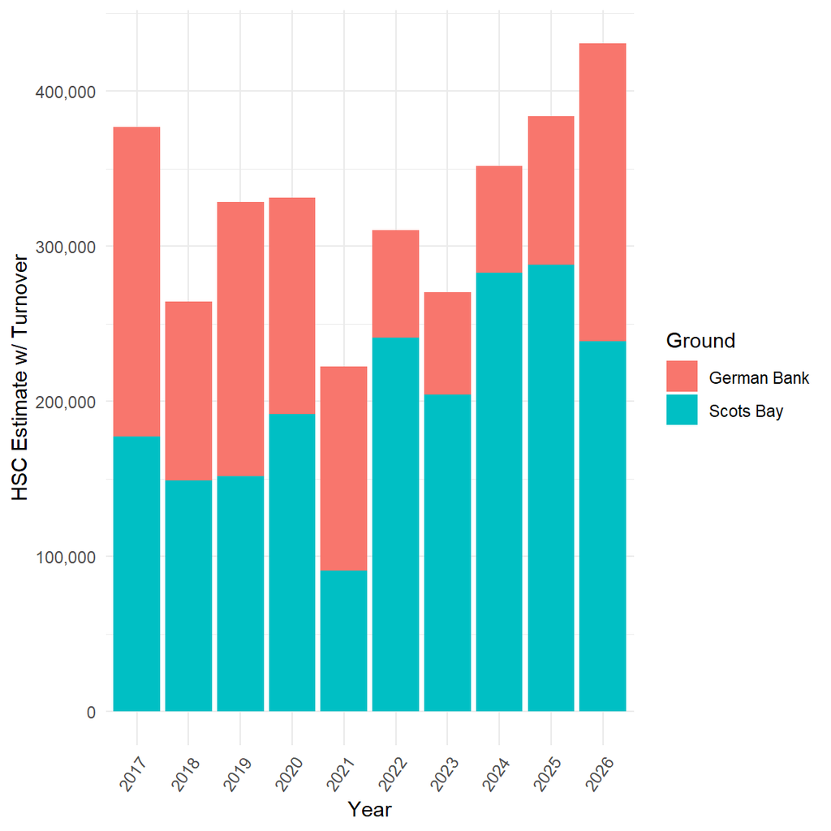

|  | Year | HSC Estimate | HSC w/ Turnover |
| --- | --- | --- | --- |
| 1 | 2026 | 508019.49977 | 430472.02 |
| 2 | 2025 | 450089 | 383743 |
| 3 | 2024 | 412033 | 351453 |
| 4 | 2023 | 325420 | 270305 |
| 5 | 2022 | 364487 | 310302 |
| 6 | 2021 | 261761 | 222431 |
| 7 | 2020 | 399729 | 331099 |
| 8 | 2019 | 404949 | 328196 |
| 9 | 2018 | 332321 | 264377 |
| 10 | 2017 | 452933 | 376674 |

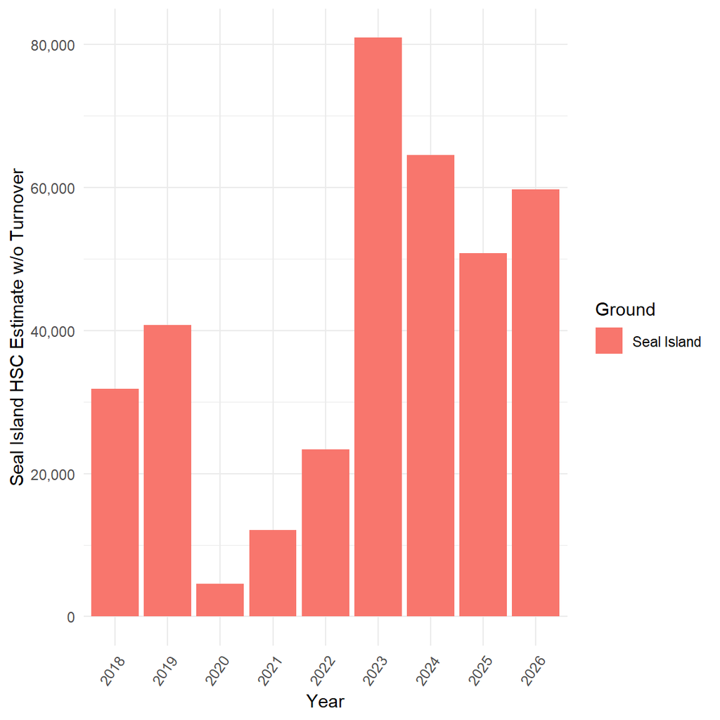

[interactive table not shown]

#### Scots Bay

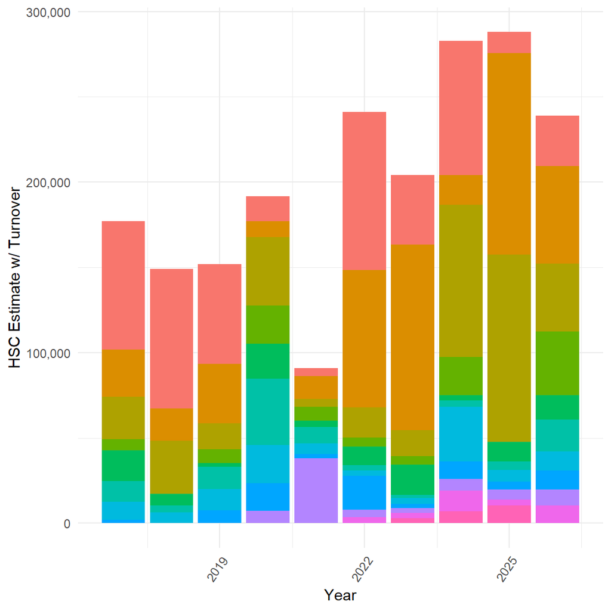

|  | Year | HSC Estimate | HSC w/ Turnover | DFO Estimate | DFO w/ Turnover |
| --- | --- | --- | --- | --- | --- |
| 1 | 2026 | 275326.20977 | 238863 |  |  |
| 2 | 2025 | 327268 | 287912 | 297308 | 275084 |
| 3 | 2024 | 326673 | 282742 | 270323 | 234216 |
| 4 | 2023 | 241538 | 204189 | 218266 | 177329 |
| 5 | 2022 | 279361 | 241020 | 305300 | 256011 |
| 6 | 2021 | 101305 | 90764 | 76803 | 69831 |
| 7 | 2020 | 221211 | 191649 | 210238 | 179059 |
| 8 | 2019 | 174472 | 151943 | 153213 | 133331 |
| 9 | 2018 | 175317 | 149018 | 159271 | 139651 |
| 10 | 2017 | 199560 | 177060 | 172855 | 142238 |

#### German Bank

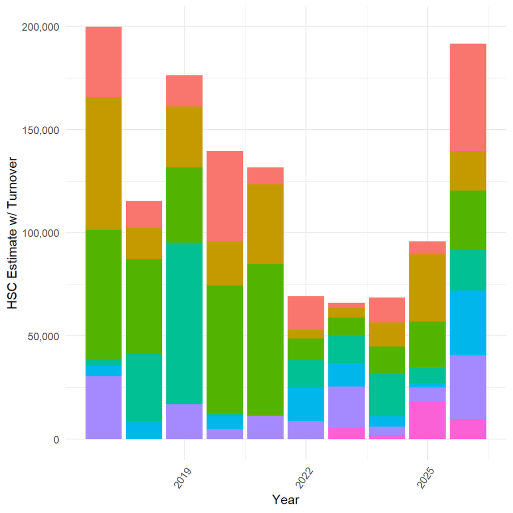

|  | Year | HSC Estimate | HSC w/ Turnover | DFO Estimate | DFO w/ Turnover |
| --- | --- | --- | --- | --- | --- |
| 1 | 2026 | 232693.29 | 191609.02 |  |  |
| 2 | 2025 | 122821 | 95831 | 178437 | 148774 |
| 3 | 2024 | 85360 | 68711 | 81720 | 67076 |
| 4 | 2023 | 83882 | 66116 | 81785 | 65237 |
| 5 | 2022 | 85126 | 69282 | 93997 | 76559 |
| 6 | 2021 | 160456 | 131667 | 155615 | 135629 |
| 7 | 2020 | 178518 | 139450 | 132299 | 107417 |
| 8 | 2019 | 230477 | 176253 | 177202 | 147139 |
| 9 | 2018 | 157004 | 115359 | 129679 | 94869 |
| 10 | 2017 | 253373 | 199614 |  | 165792 |

#### Seal Island

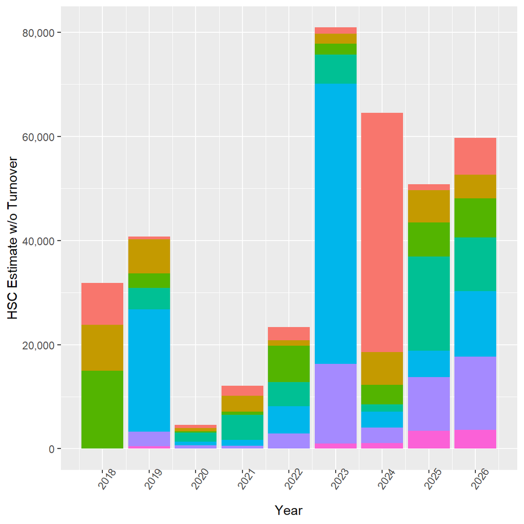

|  | Year | HSC Estimate | HSC w/ Turnover | DFO Estimate | DFO w/ Turnover |
| --- | --- | --- | --- | --- | --- |
| 1 | 2026 | 59698.8 |  |  |  |
| 2 | 2025 | 50819 |  |  |  |
| 3 | 2024 | 64504 |  | 50013 |  |
| 4 | 2023 | 80933 |  | 64707 |  |
| 5 | 2022 | 23408 |  | 21578 | 15749 |
| 6 | 2021 | 12062 |  | 10053 | 6438 |
| 7 | 2020 | 4601 |  | 4330 | 2800 |
| 8 | 2019 | 40730 |  | 32702 |  |
| 9 | 2018 | 31844 |  | 28049 |  |

### Annual SSB Estimates

#### Scots Bay

##### 2017

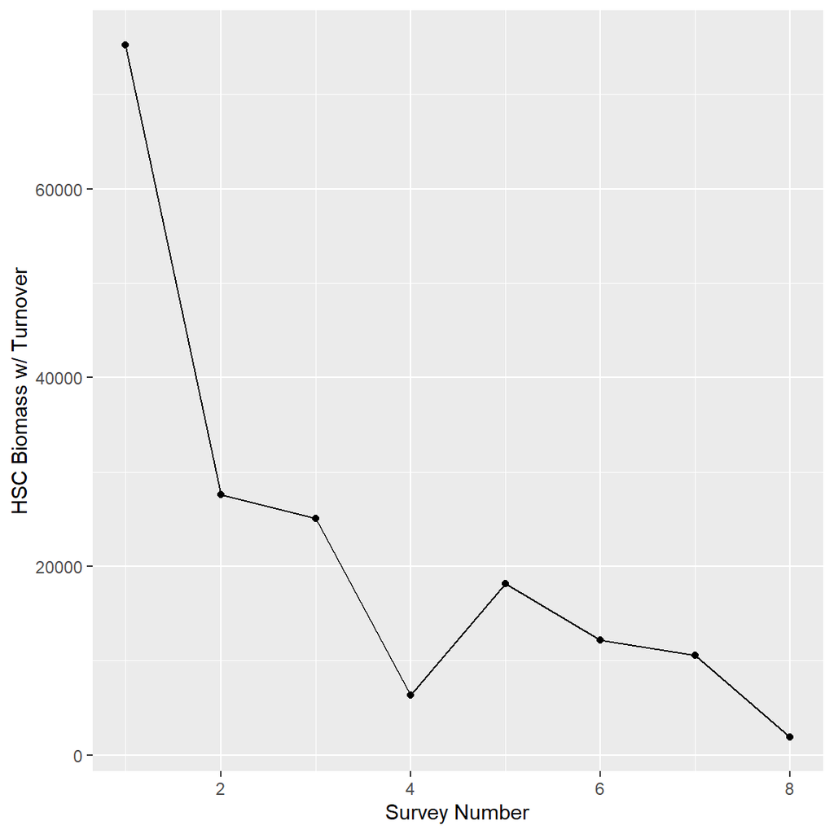

| Year | Ground | Survey Number | HSC (Turnover Adjusted) |
| --- | --- | --- | --- |
| 2017 | Scots Bay | 1 | 75258 |
| 2017 | Scots Bay | 2 | 27638 |
| 2017 | Scots Bay | 3 | 25065 |
| 2017 | Scots Bay | 4 | 6329 |
| 2017 | Scots Bay | 5 | 18126 |
| 2017 | Scots Bay | 6 | 12143 |
| 2017 | Scots Bay | 7 | 10576 |
| 2017 | Scots Bay | 8 | 1925 |

##### 2018

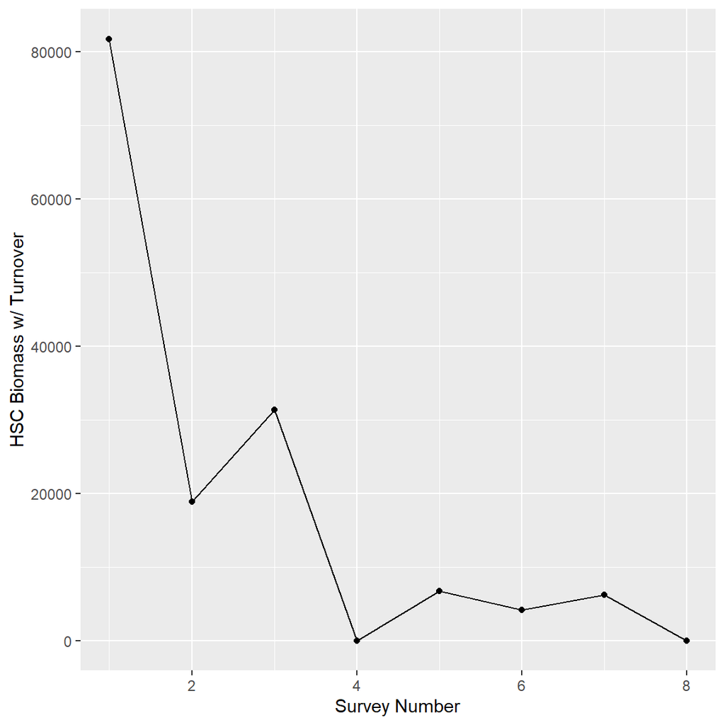

| Year | Ground | Survey Number | HSC (Turnover Adjusted) |
| --- | --- | --- | --- |
| 2018 | Scots Bay | 1 | 81722 |
| 2018 | Scots Bay | 2 | 18838 |
| 2018 | Scots Bay | 3 | 31360 |
| 2018 | Scots Bay | 4 | 0 |
| 2018 | Scots Bay | 5 | 6718 |
| 2018 | Scots Bay | 6 | 4134 |
| 2018 | Scots Bay | 7 | 6246 |
| 2018 | Scots Bay | 8 | 0 |

##### 2019

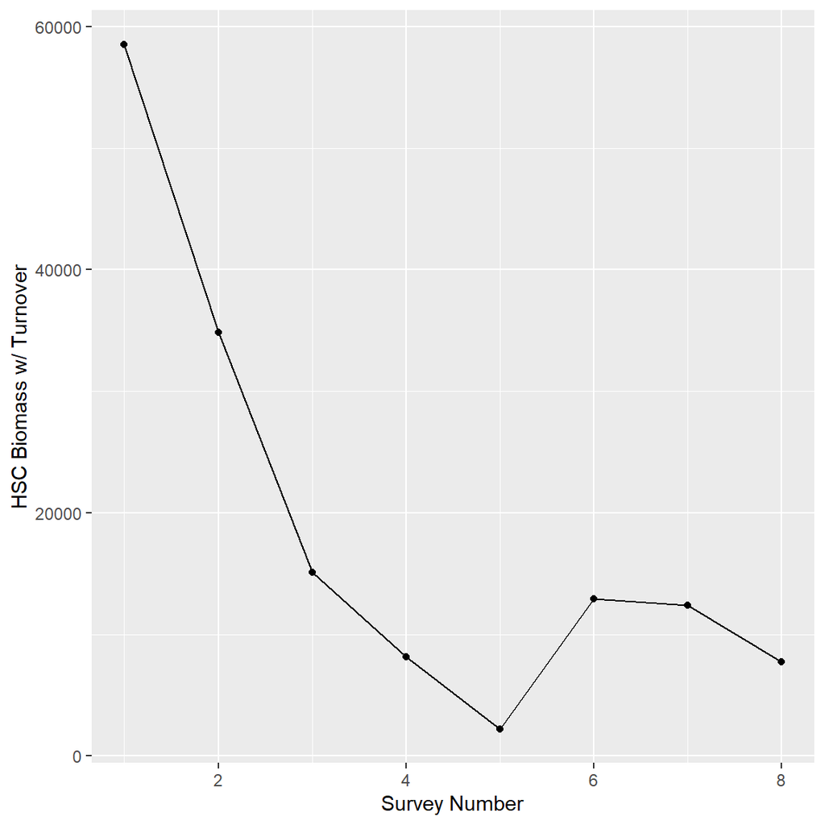

| Year | Ground | Survey Number | HSC (Turnover Adjusted) |
| --- | --- | --- | --- |
| 2019 | Scots Bay | 1 | 58532 |
| 2019 | Scots Bay | 2 | 34844 |
| 2019 | Scots Bay | 3 | 15122 |
| 2019 | Scots Bay | 4 | 8147 |
| 2019 | Scots Bay | 5 | 2228 |
| 2019 | Scots Bay | 6 | 12947 |
| 2019 | Scots Bay | 7 | 12400 |
| 2019 | Scots Bay | 8 | 7723 |

##### 2020

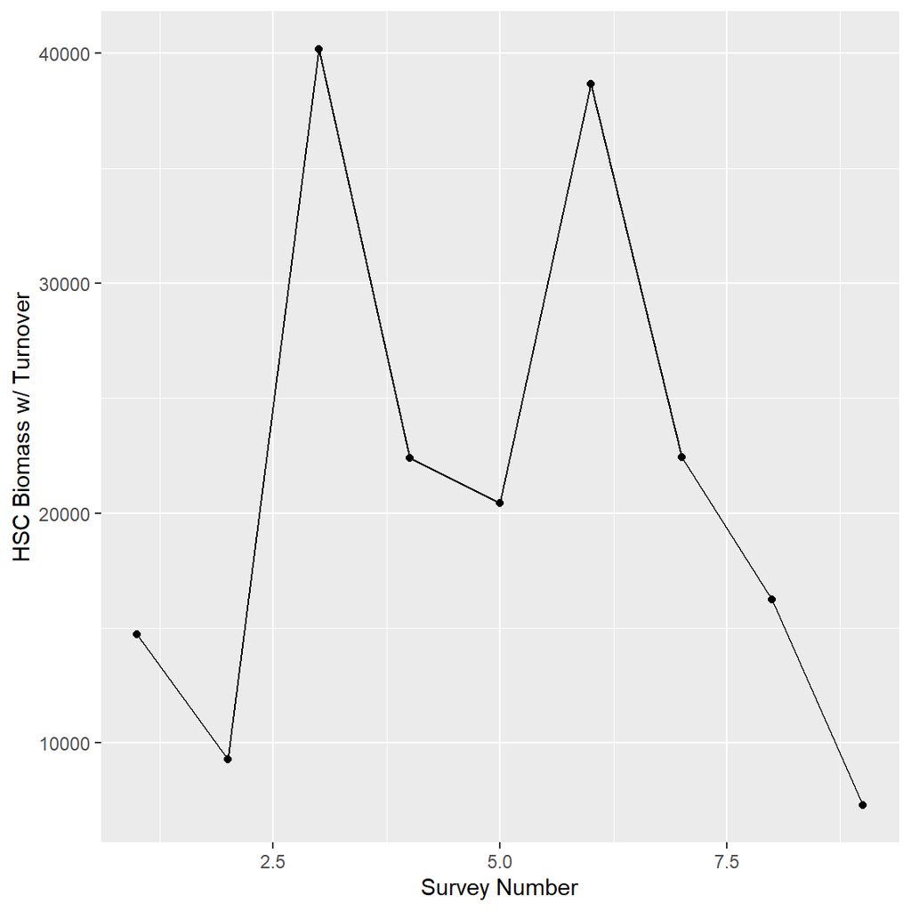

| Year | Ground | Survey Number | HSC (Turnover Adjusted) |
| --- | --- | --- | --- |
| 2020 | Scots Bay | 1 | 14718 |
| 2020 | Scots Bay | 2 | 9292 |
| 2020 | Scots Bay | 3 | 40191 |
| 2020 | Scots Bay | 4 | 22380 |
| 2020 | Scots Bay | 5 | 20435 |
| 2020 | Scots Bay | 6 | 38690 |
| 2020 | Scots Bay | 7 | 22413 |
| 2020 | Scots Bay | 8 | 16234 |
| 2020 | Scots Bay | 9 | 7296 |

##### 2021

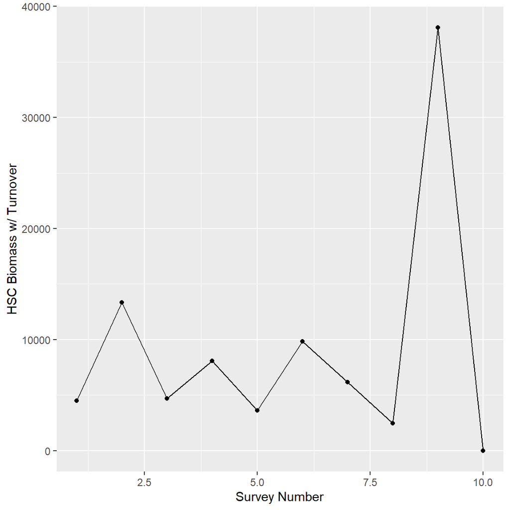

| Year | Ground | Survey Number | HSC (Turnover Adjusted) |
| --- | --- | --- | --- |
| 2021 | Scots Bay | 1 | 4502 |
| 2021 | Scots Bay | 2 | 13339 |
| 2021 | Scots Bay | 3 | 4685 |
| 2021 | Scots Bay | 4 | 8098 |
| 2021 | Scots Bay | 5 | 3602 |
| 2021 | Scots Bay | 6 | 9817 |
| 2021 | Scots Bay | 7 | 6159 |
| 2021 | Scots Bay | 8 | 2453 |
| 2021 | Scots Bay | 9 | 38109 |
| 2021 | Scots Bay | 10 | 0 |

##### 2022

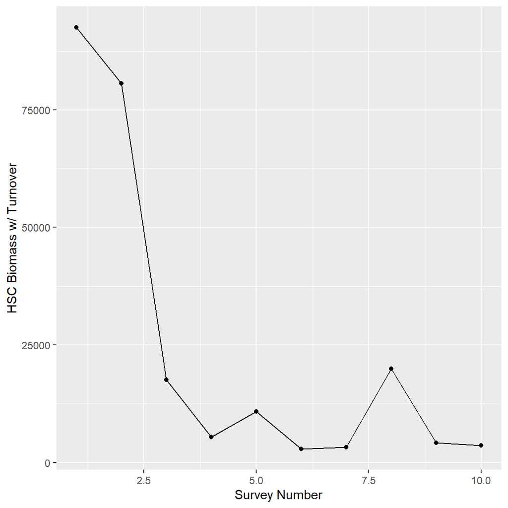

| Year | Ground | Survey Number | HSC (Turnover Adjusted) |
| --- | --- | --- | --- |
| 2022 | Scots Bay | 1 | 92542 |
| 2022 | Scots Bay | 2 | 80663 |
| 2022 | Scots Bay | 3 | 17624 |
| 2022 | Scots Bay | 4 | 5432 |
| 2022 | Scots Bay | 5 | 10869 |
| 2022 | Scots Bay | 6 | 2901 |
| 2022 | Scots Bay | 7 | 3225 |
| 2022 | Scots Bay | 8 | 19939 |
| 2022 | Scots Bay | 9 | 4212 |
| 2022 | Scots Bay | 10 | 3613 |

##### 2023

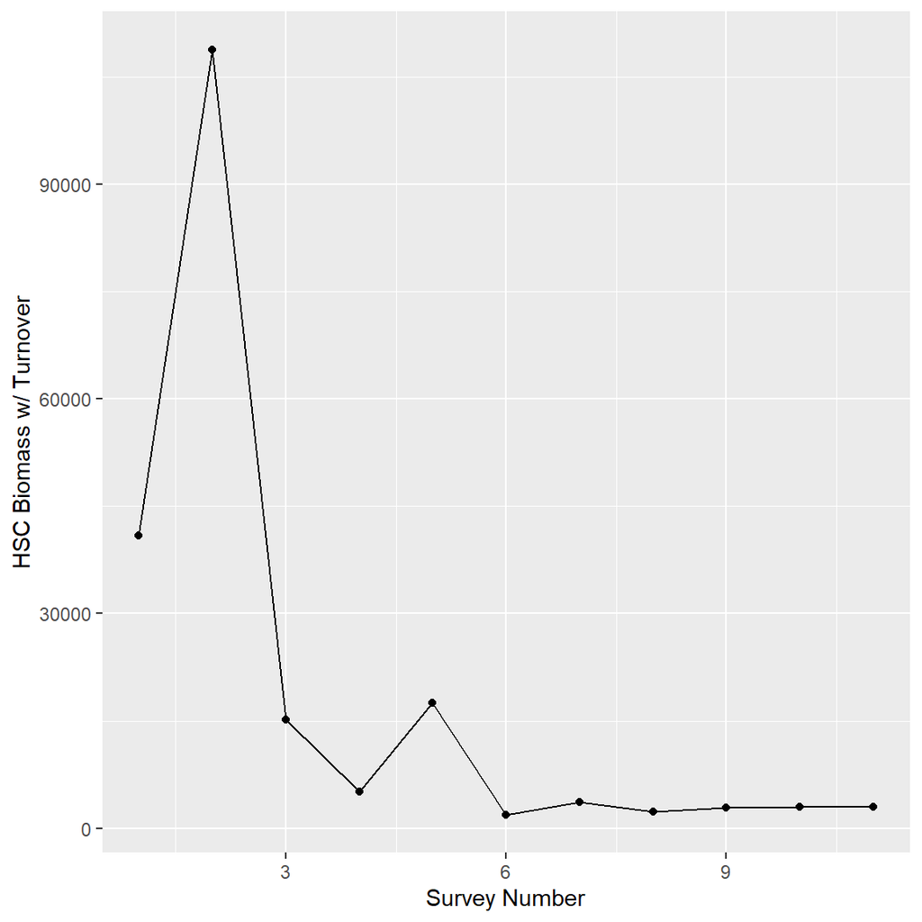

| Year | Ground | Survey Number | HSC (Turnover Adjusted) |
| --- | --- | --- | --- |
| 2023 | Scots Bay | 1 | 40856 |
| 2023 | Scots Bay | 2 | 108783 |
| 2023 | Scots Bay | 3 | 15158 |
| 2023 | Scots Bay | 4 | 5113 |
| 2023 | Scots Bay | 5 | 17575 |
| 2023 | Scots Bay | 6 | 1904 |
| 2023 | Scots Bay | 7 | 3616 |
| 2023 | Scots Bay | 8 | 2300 |
| 2023 | Scots Bay | 9 | 2916 |
| 2023 | Scots Bay | 10 | 2997 |
| 2023 | Scots Bay | 11 | 2971 |

##### 2024

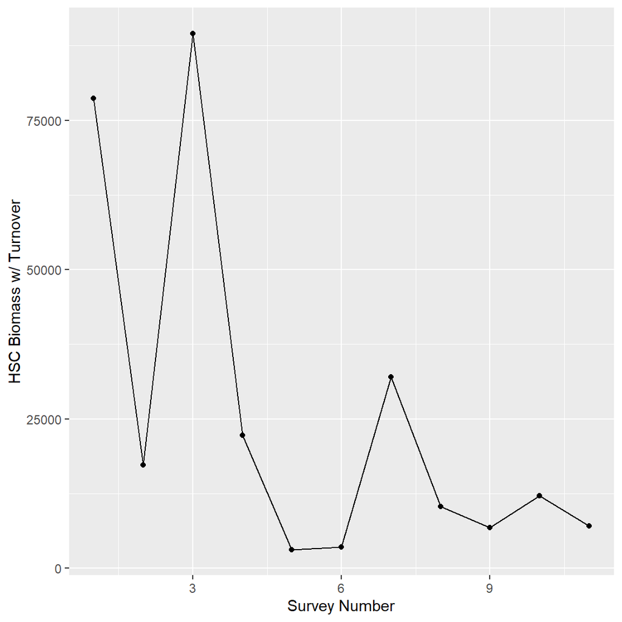

| Year | Ground | Survey Number | HSC (Turnover Adjusted) |
| --- | --- | --- | --- |
| 2024 | Scots Bay | 1 | 78662 |
| 2024 | Scots Bay | 2 | 17255 |
| 2024 | Scots Bay | 3 | 89523 |
| 2024 | Scots Bay | 4 | 22278 |
| 2024 | Scots Bay | 5 | 3123 |
| 2024 | Scots Bay | 6 | 3560 |
| 2024 | Scots Bay | 7 | 32016 |
| 2024 | Scots Bay | 8 | 10296 |
| 2024 | Scots Bay | 9 | 6810 |
| 2024 | Scots Bay | 10 | 12121 |
| 2024 | Scots Bay | 11 | 7098 |

##### 2025

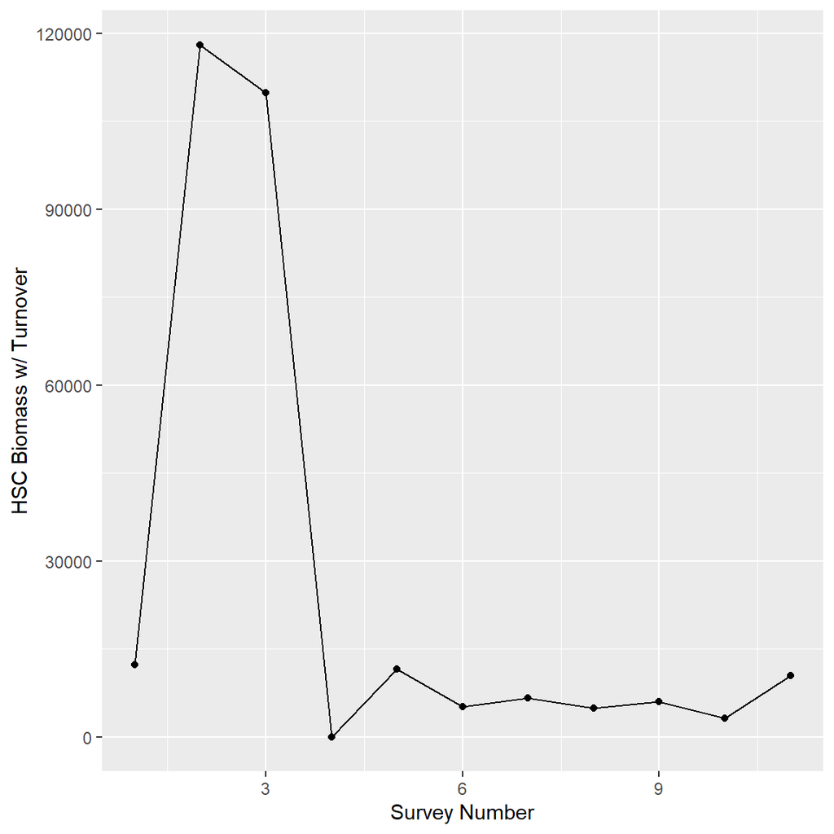

| Year | Ground | Survey Number | HSC (Turnover Adjusted) |
| --- | --- | --- | --- |
| 2025 | Scots Bay | 1 | 12306 |
| 2025 | Scots Bay | 2 | 118023 |
| 2025 | Scots Bay | 3 | 109821 |
| 2025 | Scots Bay | 4 | 0 |
| 2025 | Scots Bay | 5 | 11509 |
| 2025 | Scots Bay | 6 | 5137 |
| 2025 | Scots Bay | 7 | 6612 |
| 2025 | Scots Bay | 8 | 4916 |
| 2025 | Scots Bay | 9 | 5948 |
| 2025 | Scots Bay | 10 | 3169 |
| 2025 | Scots Bay | 11 | 10471 |

##### 2026

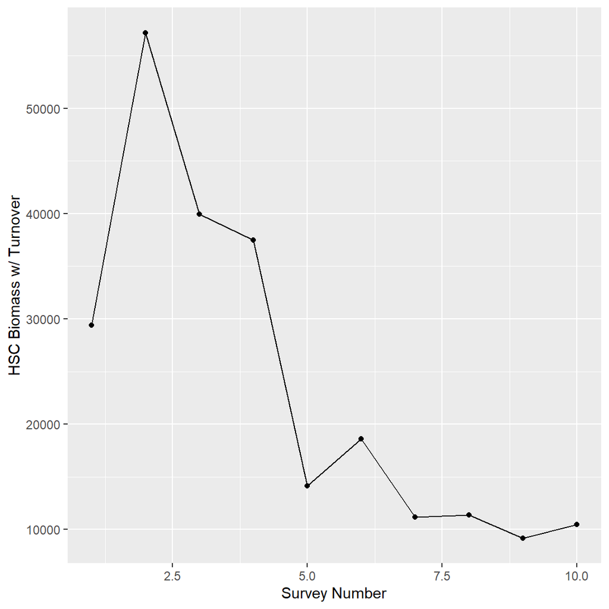

| Year | Ground | Survey Number | HSC (Turnover Adjusted) |
| --- | --- | --- | --- |
| 2026 | Scots Bay | 1 | 29384 |
| 2026 | Scots Bay | 2 | 57169 |
| 2026 | Scots Bay | 3 | 39929 |
| 2026 | Scots Bay | 4 | 37478 |
| 2026 | Scots Bay | 5 | 14137 |
| 2026 | Scots Bay | 6 | 18616 |
| 2026 | Scots Bay | 7 | 11144 |
| 2026 | Scots Bay | 8 | 11377 |
| 2026 | Scots Bay | 9 | 9178 |
| 2026 | Scots Bay | 10 | 10451 |

#### German Bank

##### 2017

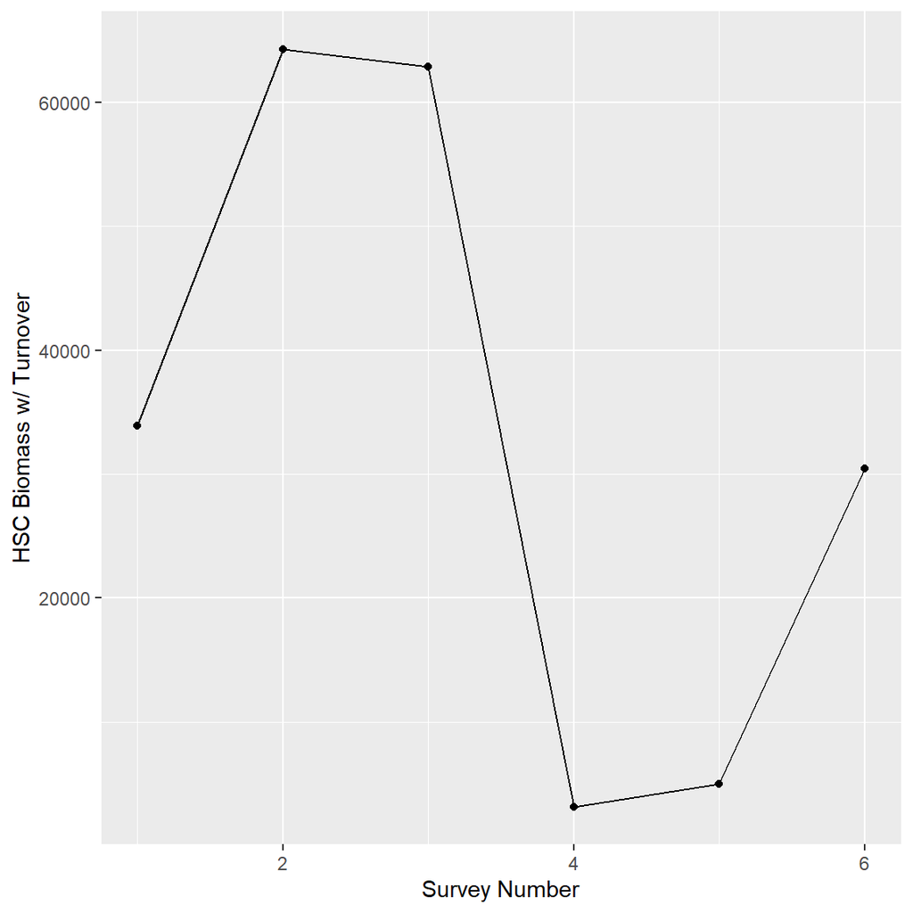

| Year | Ground | Survey Number | HSC (Turnover Adjusted) |
| --- | --- | --- | --- |
| 2017 | German Bank | 1 | 33892 |
| 2017 | German Bank | 2 | 64296 |
| 2017 | German Bank | 3 | 62869 |
| 2017 | German Bank | 4 | 3148 |
| 2017 | German Bank | 5 | 4984 |
| 2017 | German Bank | 6 | 30425 |

##### 2018

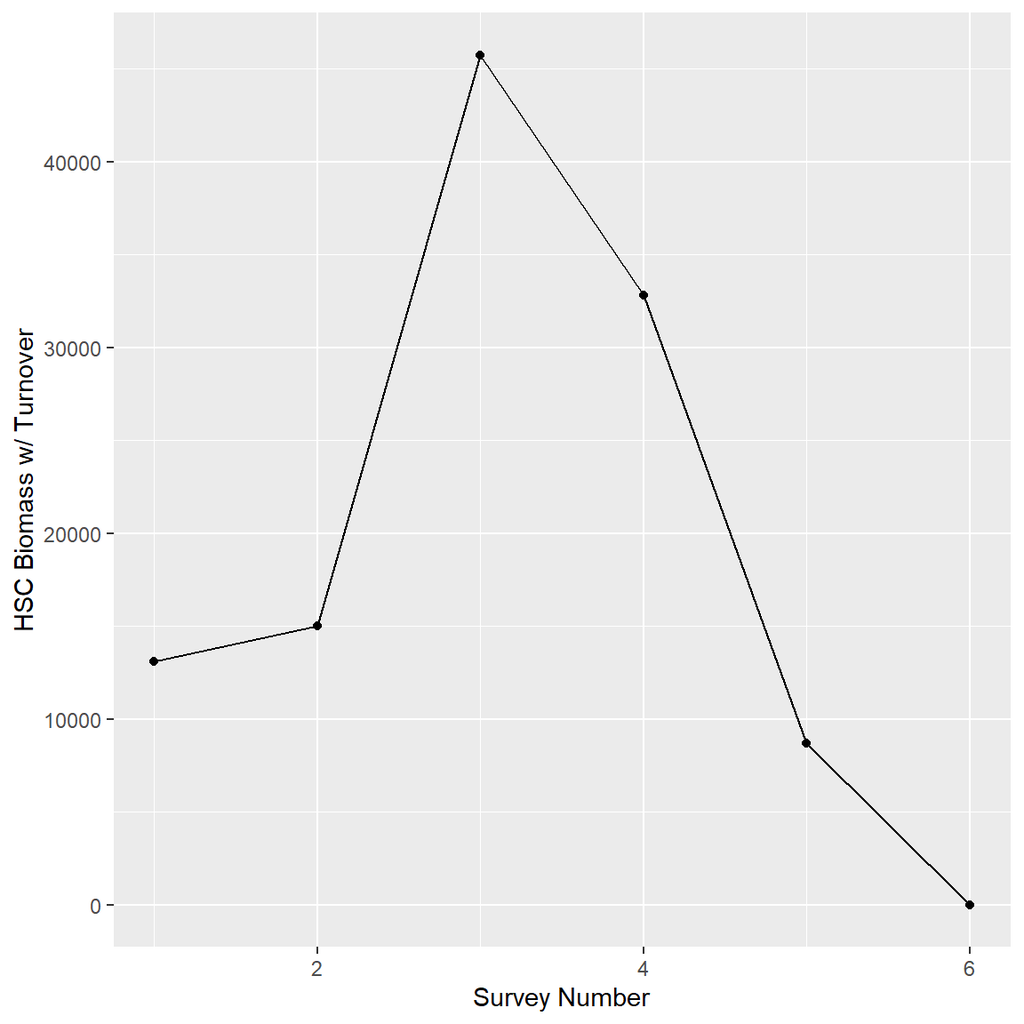

| Year | Ground | Survey Number | HSC (Turnover Adjusted) |
| --- | --- | --- | --- |
| 2018 | German Bank | 1 | 13097 |
| 2018 | German Bank | 2 | 15022 |
| 2018 | German Bank | 3 | 45742 |
| 2018 | German Bank | 4 | 32813 |
| 2018 | German Bank | 5 | 8685 |
| 2018 | German Bank | 6 | 0 |

##### 2019

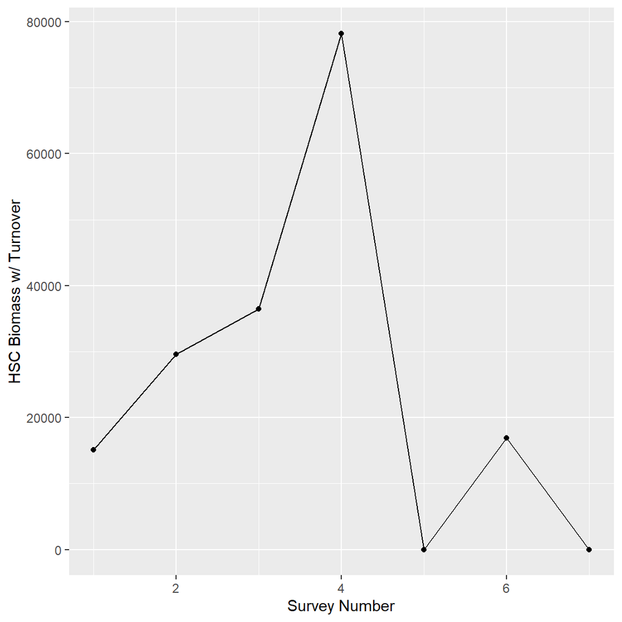

| Year | Ground | Survey Number | HSC (Turnover Adjusted) |
| --- | --- | --- | --- |
| 2019 | German Bank | 1 | 15110 |
| 2019 | German Bank | 2 | 29583 |
| 2019 | German Bank | 3 | 36467 |
| 2019 | German Bank | 4 | 78214 |
| 2019 | German Bank | 5 | 0 |
| 2019 | German Bank | 6 | 16879 |
| 2019 | German Bank | 7 | 0 |

##### 2020

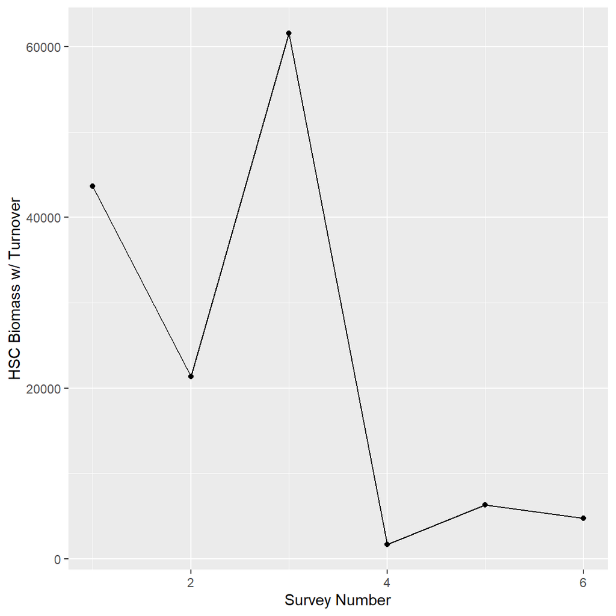

| Year | Ground | Survey Number | HSC (Turnover Adjusted) |
| --- | --- | --- | --- |
| 2020 | German Bank | 1 | 43690 |
| 2020 | German Bank | 2 | 21377 |
| 2020 | German Bank | 3 | 61580 |
| 2020 | German Bank | 4 | 1713 |
| 2020 | German Bank | 5 | 6329 |
| 2020 | German Bank | 6 | 4761 |

##### 2021

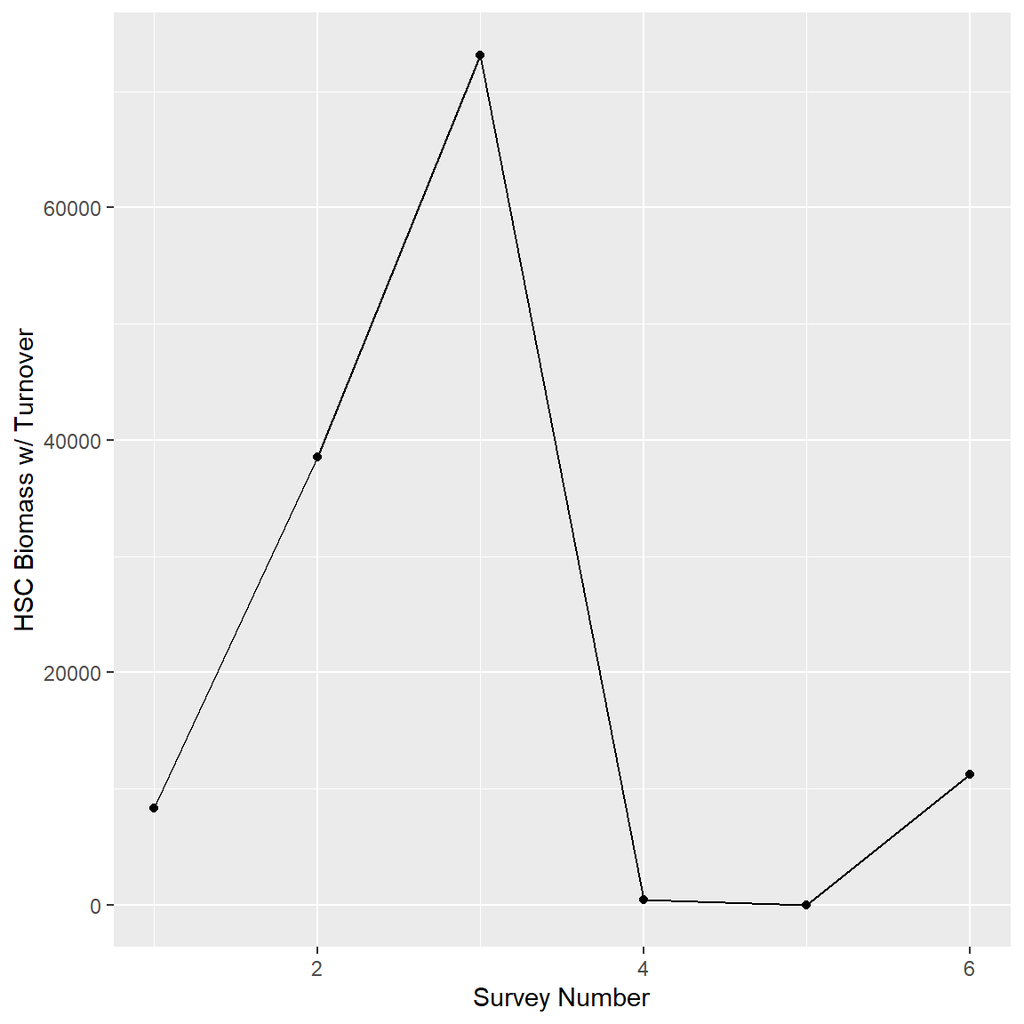

| Year | Ground | Survey Number | HSC (Turnover Adjusted) |
| --- | --- | --- | --- |
| 2021 | German Bank | 1 | 8338 |
| 2021 | German Bank | 2 | 38551 |
| 2021 | German Bank | 3 | 73120 |
| 2021 | German Bank | 4 | 461 |
| 2021 | German Bank | 5 | 0 |
| 2021 | German Bank | 6 | 11197 |

##### 2022

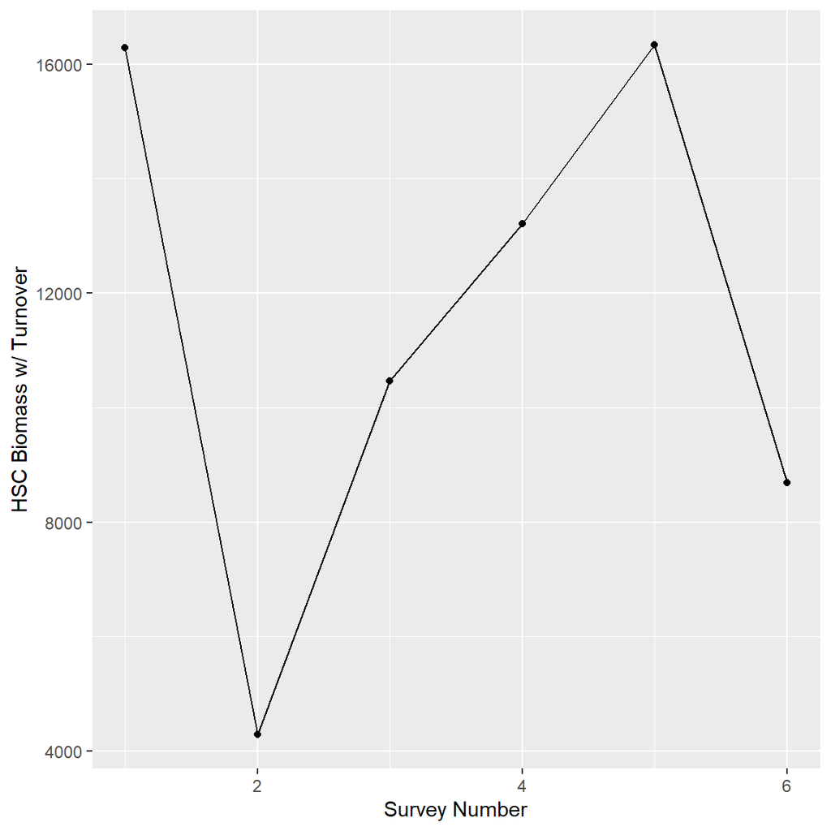

| Year | Ground | Survey Number | HSC (Turnover Adjusted) |
| --- | --- | --- | --- |
| 2022 | German Bank | 1 | 16285 |
| 2022 | German Bank | 2 | 4296 |
| 2022 | German Bank | 3 | 10464 |
| 2022 | German Bank | 4 | 13216 |
| 2022 | German Bank | 5 | 16337 |
| 2022 | German Bank | 6 | 8684 |

##### 2023

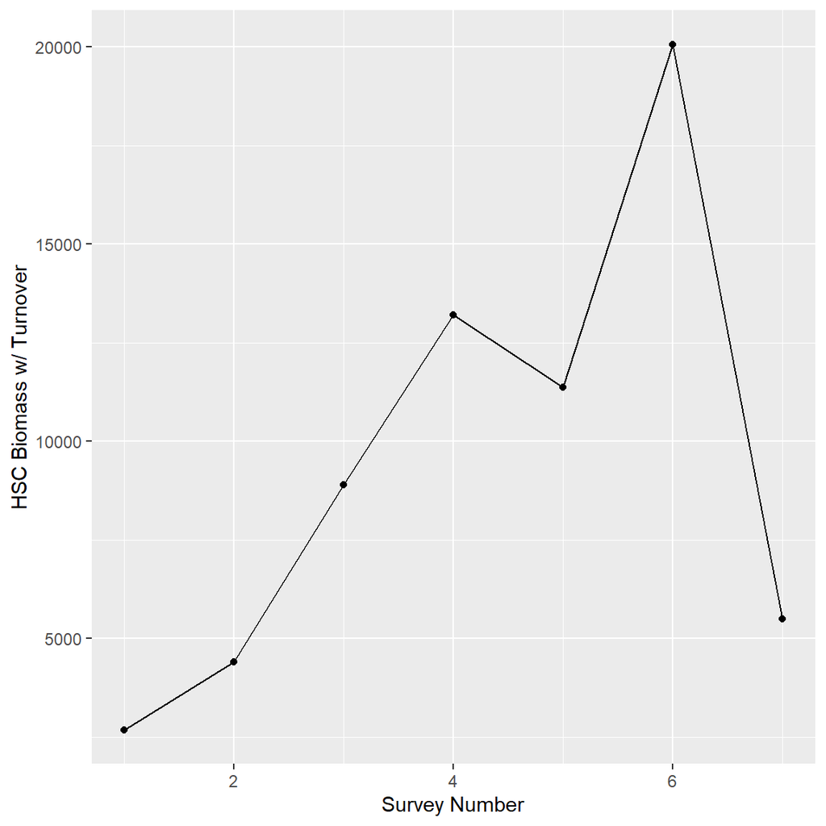

| Year | Ground | Survey Number | HSC (Turnover Adjusted) |
| --- | --- | --- | --- |
| 2023 | German Bank | 1 | 2687 |
| 2023 | German Bank | 2 | 4406 |
| 2023 | German Bank | 3 | 8901 |
| 2023 | German Bank | 4 | 13203 |
| 2023 | German Bank | 5 | 11360 |
| 2023 | German Bank | 6 | 20057 |
| 2023 | German Bank | 7 | 5502 |

##### 2024

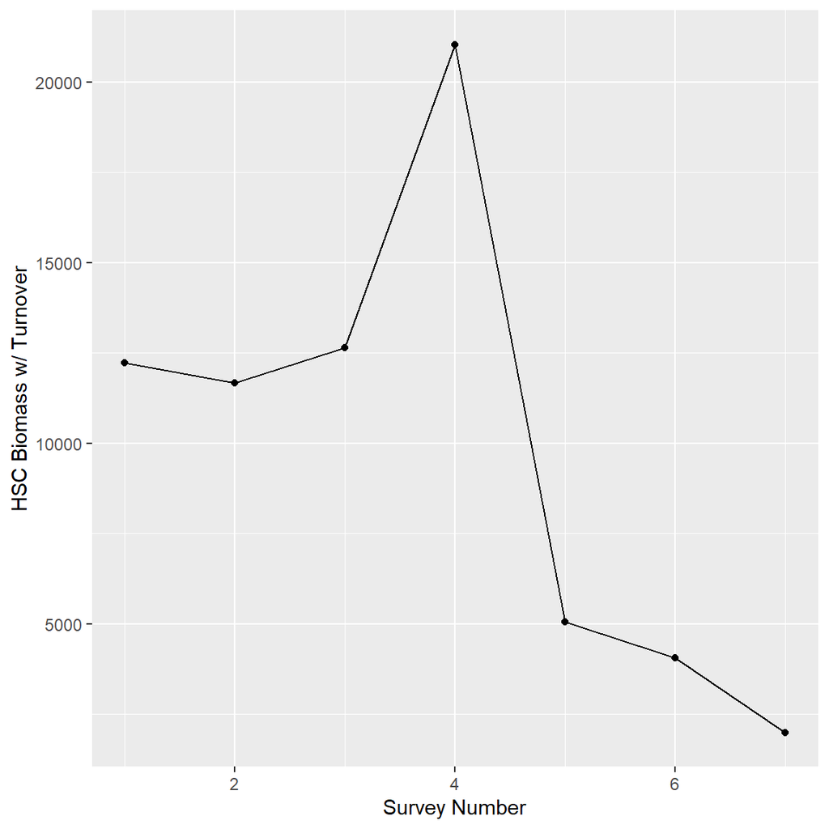

| Year | Ground | Survey Number | HSC (Turnover Adjusted) |
| --- | --- | --- | --- |
| 2024 | German Bank | 1 | 12233 |
| 2024 | German Bank | 2 | 11668 |
| 2024 | German Bank | 3 | 12639 |
| 2024 | German Bank | 4 | 21033 |
| 2024 | German Bank | 5 | 5068 |
| 2024 | German Bank | 6 | 4071 |
| 2024 | German Bank | 7 | 1999 |

##### 2025

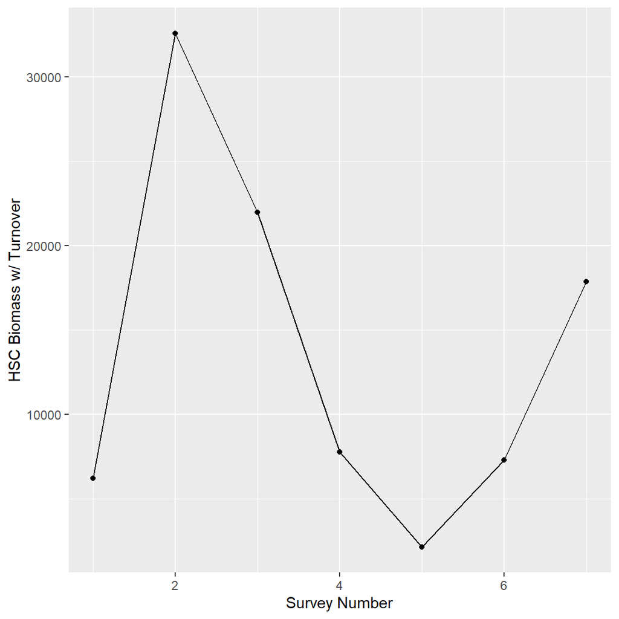

| Year | Ground | Survey Number | HSC (Turnover Adjusted) |
| --- | --- | --- | --- |
| 2025 | German Bank | 1 | 6194 |
| 2025 | German Bank | 2 | 32592 |
| 2025 | German Bank | 3 | 21986 |
| 2025 | German Bank | 4 | 7753 |
| 2025 | German Bank | 5 | 2138 |
| 2025 | German Bank | 6 | 7291 |
| 2025 | German Bank | 7 | 17877 |

##### 2026

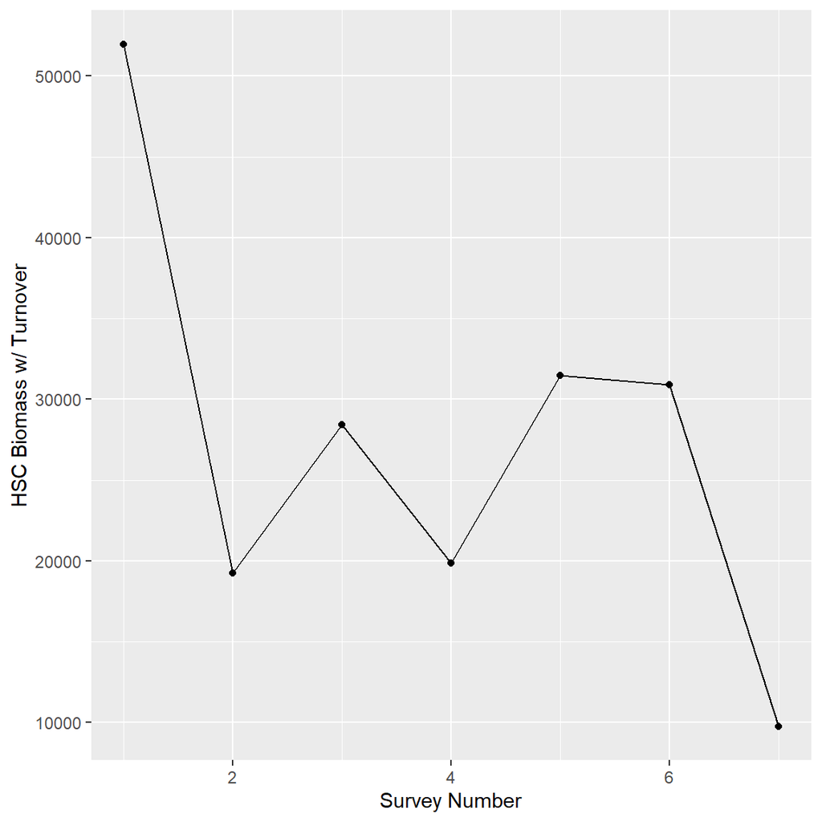

| Year | Ground | Survey Number | HSC (Turnover Adjusted) |
| --- | --- | --- | --- |
| 2026 | German Bank | 1 | 51965.02 |
| 2026 | German Bank | 2 | 19220.00 |
| 2026 | German Bank | 3 | 28409.00 |
| 2026 | German Bank | 4 | 19866.00 |
| 2026 | German Bank | 5 | 31468.00 |
| 2026 | German Bank | 6 | 30919.00 |
| 2026 | German Bank | 7 | 9762.00 |

#### Seal Island

##### 2017

[figure not shown]

| Year | Ground | Survey Number | HSC without Turnover |
| --- | --- | --- | --- |

##### 2018

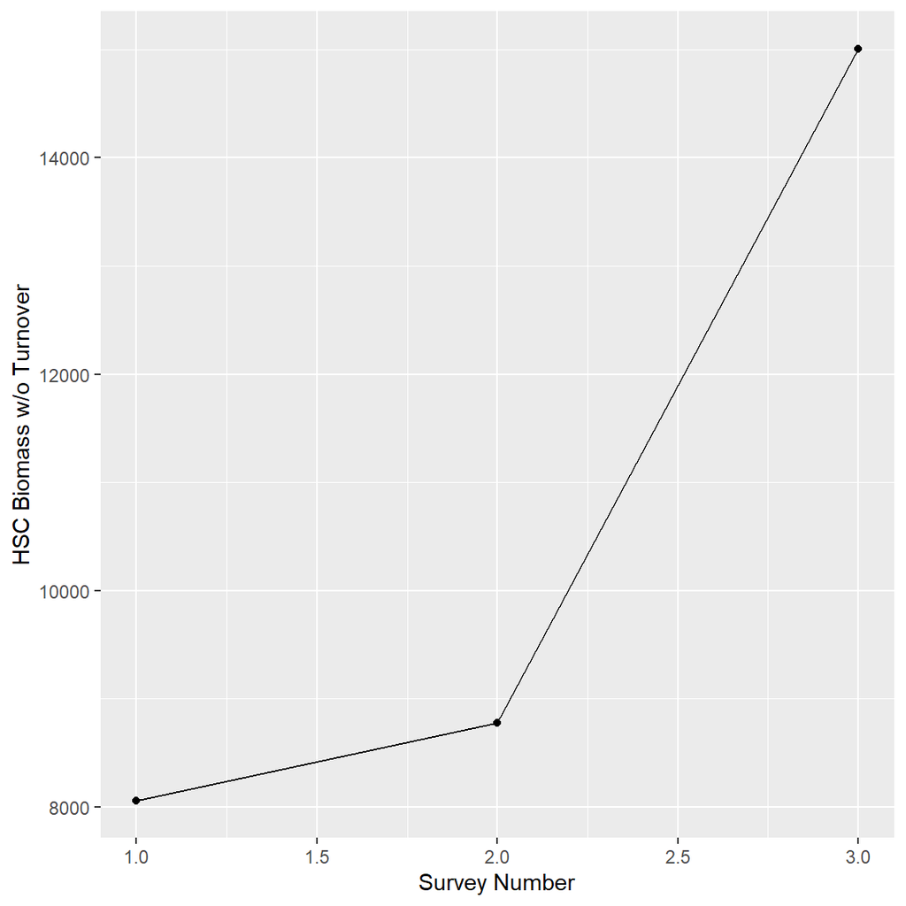

| Year | Ground | Survey Number | HSC without Turnover |
| --- | --- | --- | --- |
| 2018 | Seal Island | 1 | 8061 |
| 2018 | Seal Island | 2 | 8776 |
| 2018 | Seal Island | 3 | 15007 |

##### 2019

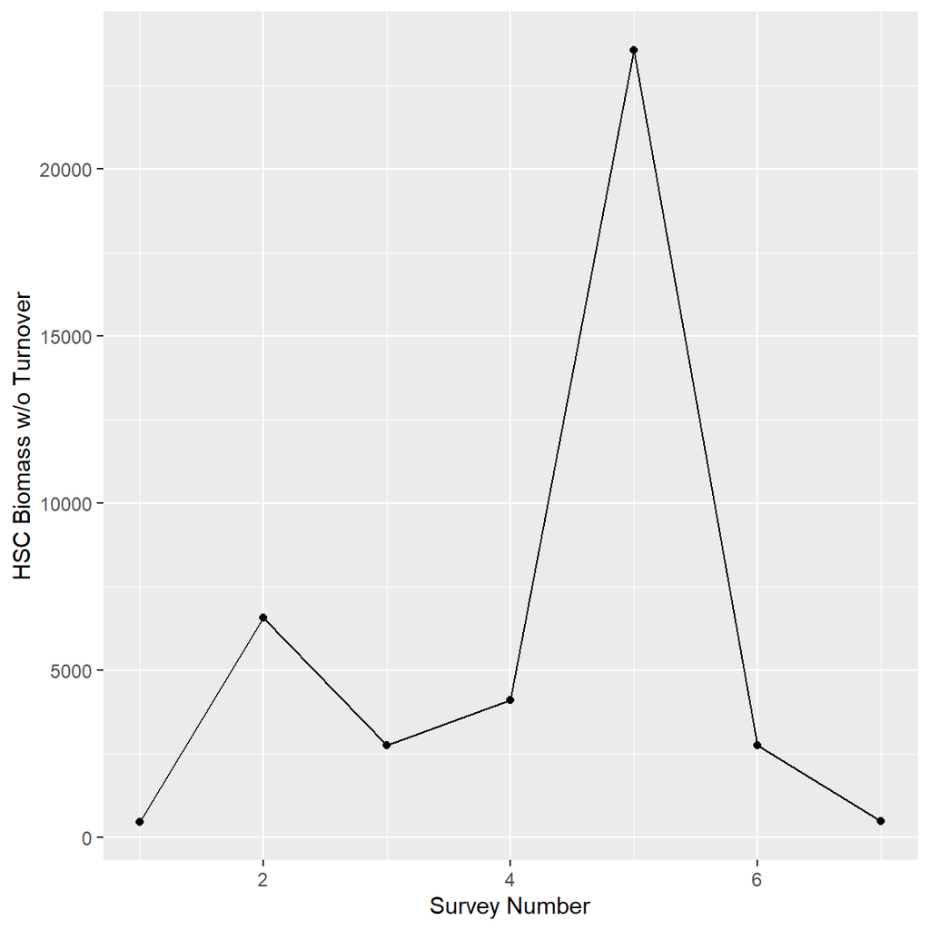

| Year | Ground | Survey Number | HSC without Turnover |
| --- | --- | --- | --- |
| 2019 | Seal Island | 1 | 477 |
| 2019 | Seal Island | 2 | 6574 |
| 2019 | Seal Island | 3 | 2752 |
| 2019 | Seal Island | 4 | 4108 |
| 2019 | Seal Island | 5 | 23555 |
| 2019 | Seal Island | 6 | 2761 |
| 2019 | Seal Island | 7 | 503 |

##### 2020

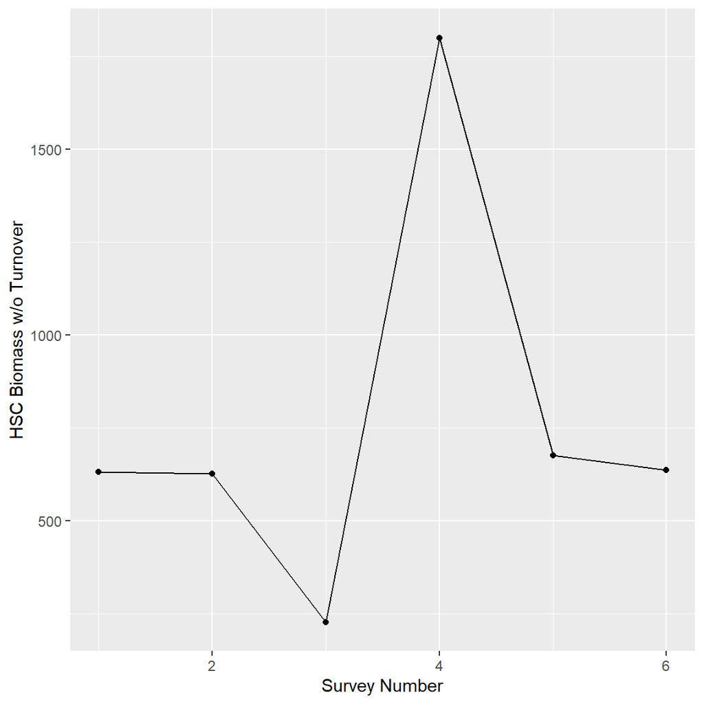

| Year | Ground | Survey Number | HSC without Turnover |
| --- | --- | --- | --- |
| 2020 | Seal Island | 1 | 632 |
| 2020 | Seal Island | 2 | 627 |
| 2020 | Seal Island | 3 | 228 |
| 2020 | Seal Island | 4 | 1800 |
| 2020 | Seal Island | 5 | 677 |
| 2020 | Seal Island | 6 | 637 |

##### 2021

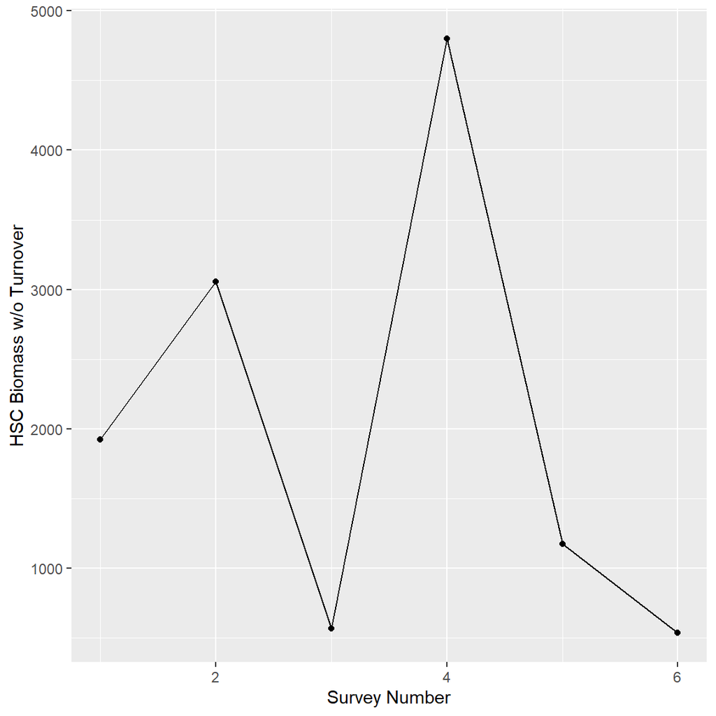

| Year | Ground | Survey Number | HSC without Turnover |
| --- | --- | --- | --- |
| 2021 | Seal Island | 1 | 1922 |
| 2021 | Seal Island | 2 | 3057 |
| 2021 | Seal Island | 3 | 568 |
| 2021 | Seal Island | 4 | 4801 |
| 2021 | Seal Island | 5 | 1176 |
| 2021 | Seal Island | 6 | 538 |

##### 2022

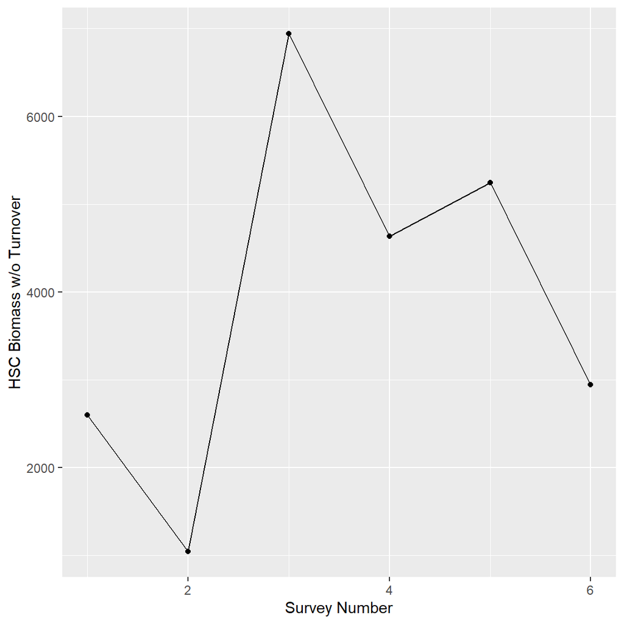

| Year | Ground | Survey Number | HSC without Turnover |
| --- | --- | --- | --- |
| 2022 | Seal Island | 1 | 2598 |
| 2022 | Seal Island | 2 | 1048 |
| 2022 | Seal Island | 3 | 6941 |
| 2022 | Seal Island | 4 | 4634 |
| 2022 | Seal Island | 5 | 5243 |
| 2022 | Seal Island | 6 | 2944 |